# fishes: Establishing the signal above the noise

copyright Mary Lesperance

4/10/2022

# 1 R code for paper

“Establishing the signal above the noise: Accounting for an environmental background in the detection and quantification of salmonid environmental DNA”, *fishes* , 2022 by Morgan D. Hocking, Jeffrey C. MacAdams, Michael J. Allison, Lauren C. Bergman, Robert Sneiderman Ben F. Koop, Brian M. Starzomski, Mary L. Lesperance and Caren C. Helbing; 7: 266. DOI: 10.3390/fishes7050266

# 2 Outline

**Develop Low/High Copy Standard curves for eONKI4; apply to Density and Dilution series**

1. 1. Use eLowQuant code (copied here) with gBlock data for eONKI4 to develop a standard curve for the samples with less than 100% detections. We used the no-intercept model, however, code for the intercept model is included here. The eONKI4 gBlock data is in file GEDWG_LOD_DATA3.csv. CalibS0.table and CalibS0.table0 contain the SQ estimtes SQ0’s and SE_SQ0’s as well as model estimates and their standard errors for the intercept and no intercept models respectively for sample sizes 8, 16, 24, 32. The Limits of Blank (LOB) and Detection (LOD) are computed using the Binomial-Poisson model.
2. 2. Weighted linear regression is used to develop a standard curve for the high copy data using gBlock Cq data, GEDWG_LOD_DATA3.csv, eONKI4 data.
3. The Density Experiment - The weighted linear regression model is used to estimate copy number. Log_2 copy number is plotted versus log_2 biomass, and the relationship is modelled using another weighted linear regression model.
4. The Dilution Experiment - Both standard curves are used to estimate copy numbers for the Dilution experiment.
5. The Background eDNA copy number is estimated using the negative controls (SQ=0) from both the Density and Dilution experiments.
6. The Limits of Blank and Detection, adjusted for Background, (LOB-B and LOD-B) are computed using the Binomial-Poisson model and the estimated Background eDNA.
7. The Dilution Experiment log_2 copy number estimates are plotted versus log_2 flow together with the adjusted limits of blank and detection. A Bent Cable model is fitted to the data.

# 3 First run eLowQuant with GEDWG_LOD_DATA#.csv - Extract eONKI4

## 3.1 eLowQuant Instructions copied here

This file performs the computations in the publication, ‘A Statistical Model for Calibration and Computation of Detection and Quantification Limits for Low Copy Number Environmental DNA samples’ by Lesperance, Allison, Bergman, Hocking, Helbing, *Environmental DNA*, 2021, 00, 1-12 https://doi.org/10.1002/edn3.220.

- Create a folder call Outputs in your working directory.
- Put your data file in your working directory and put the name of the file in the chunk labeled ‘READIN’ below.
- Data set csv file requirements. Columns: Target, Lab, Cq, SQ
- For nondetects, set Cq to be empty or NA value
- For negative controls, set Sq to be empty or 0 or NA value
- Include negative controls (no template controls or NTCs) in the csv file!
- DO NOT DUPLICATE Target names over different Labs!!
- This code uses observations with nonempty data and where phat <1 (num detect<num technical replicates)
- Only the SQ’s up to the first one with phat==1 are used.
- Allows for variable numbers of SQ levels per Target.
- Assumes SQs == NA are zero, i.e. are negative controls.
- The code uses the R function optim. A convergence code 0 indicates successful completion.
- Ignore warnings if results are sensible.
- EXECUTE EACH CHUNK LOOKING AT THE OUTPUT. IN PARTICULAR, LOOK AT THE GRAPHS IN THE CHUNK CALLED ‘PlotPois’ TO DETERMINE IF THE MODEL IS APPROPRIATE. IT IS NOT APPROPRIATE IF ‘lm Rsq’ is small, i.e. near zero!
- You can send results to files by setting the sink.indicator and Manusink to TRUE and running the code in RStudio. This currently does not work for all results files when knitting.
- If you wish to knit to pdf AND you do NOT have a version of Latex installed on your computer, then run the following in your RStudio console:  
  install.packages(“tinytex”); tinytex::install_tinytex()

## 3.2 Read in Data

Data should be in the form of a csv file with column names: Target, Lab, Cq, SQ.

Target is the name of the assay,  
Lab is the lab name,  
Cq is the cycle threshold where a *missing* Cq is a reaction *nondetect*,  
SQ is the starting quantity where missing values are assumed to be zero.

It is important to include the negative controls (i.e. SQ=0)!

## 3.3 Pick out the eONKI4 data only

```
## Number row and columns:   176 10
##  Data Summary
```

```
##     Target          Cq              SQ             Lab          Well
##  eONKI4:176   Min.   :21.11   Min.   :    0.03   UVIC:176   Length:176
##               1st Qu.:29.03   1st Qu.:    0.16              Class :character
##               Median :33.33   Median :    4.00              Mode  :character
##               Mean   :32.50   Mean   : 3562.50
##               3rd Qu.:36.34   3rd Qu.:  100.00
##               Max.   :46.66   Max.   :62500.00
##               NA's   :52
##     Fluor              Sample            Content             Plate
##  Length:176         Length:176         Length:176         Length:176
##  Class :character   Class :character   Class :character   Class :character
##  Mode  :character   Mode  :character   Mode  :character   Mode  :character
##
##
##
##
##   estimated.SQ
##  Min.   : NA
##  1st Qu.: NA
##  Median : NA
##  Mean   :NaN
##  3rd Qu.: NA
##  Max.   : NA
##  NA's   :176
```

## 3.4 Process/Summarize samples by Target/Sq; Compute the Poisson estimates of Sq

Hindson et al “High-Throughput Droplet Digital PCR System for Absolute Quantitation of DNA Copy Number”, Anal. Chem., 2011, 83 (22), pp 8604–8610 use a Poisson approximation for quantification. Before that, Dube et al. 2008, “Mathematical analysis of copy number variation in a DNA sample using digital PCR on a nanofluidic device”, PloS One, Vol 3, Issue 8, e2876, model the number of molecules in each chamber as a Poisson process, giving the relationship between $p$ and $\lambda$.

```
## [1] 11 13
```

```
##
##
## Table: UVIC
##
## Target          SQ   detect    n   lamhat    phat
## -------  ---------  -------  ---  -------  ------
## eONKI4    0.00e+00        0   24    0.000   0.000
## eONKI4    3.20e-02        3   24    0.134   0.125
## eONKI4    1.60e-01        6   24    0.288   0.250
## eONKI4    8.00e-01       14   24    0.875   0.583
## eONKI4    4.00e+00       21   24    2.079   0.875
## eONKI4    2.00e+01       24   24      Inf   1.000
## eONKI4    1.00e+02       24   24      Inf   1.000
## eONKI4    5.00e+02        8    8      Inf   1.000
## eONKI4    2.50e+03        8    8      Inf   1.000
## eONKI4    1.25e+04        8    8      Inf   1.000
## eONKI4    6.25e+04        8    8      Inf   1.000
```

## 3.5 Plot the Poisson estimates (and CI) of Sq for levels that had non-detects

Only the first levels of SQ that had non-detects are analyzed. Red line is least squares linear regression line.

LOOK AT THE GRAPHS IN THE CHUNK CALLED ‘PlotPois’ TO DETERMINE IF THE MODEL IS APPROPRIATE. IT IS NOT APPROPRIATE IF ‘lm Rsq’, the linear model R-square, is small, i.e. near zero!

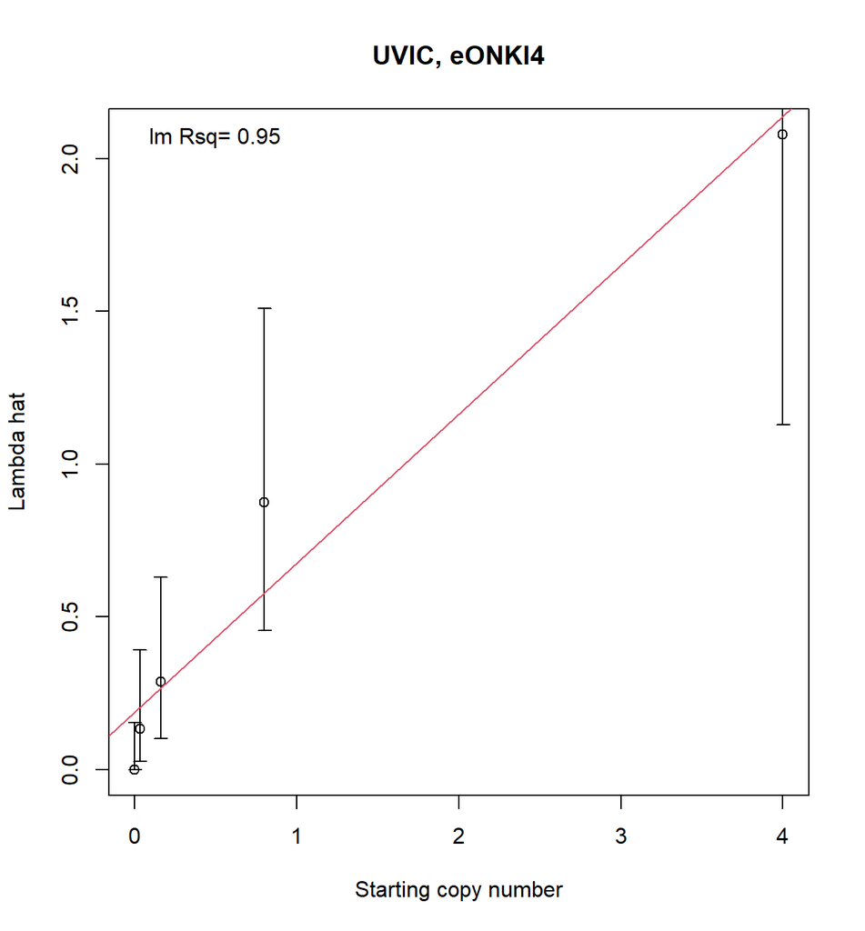

Both the intercept and no intercept models are fit to the data. The ‘best’ of the two models is the one with the largest Likelihood Ratio test p-value. The ‘best’ model will be identified in the chunk called *Manuscript*.

## 3.6 Estimate Poisson models - no intercept model

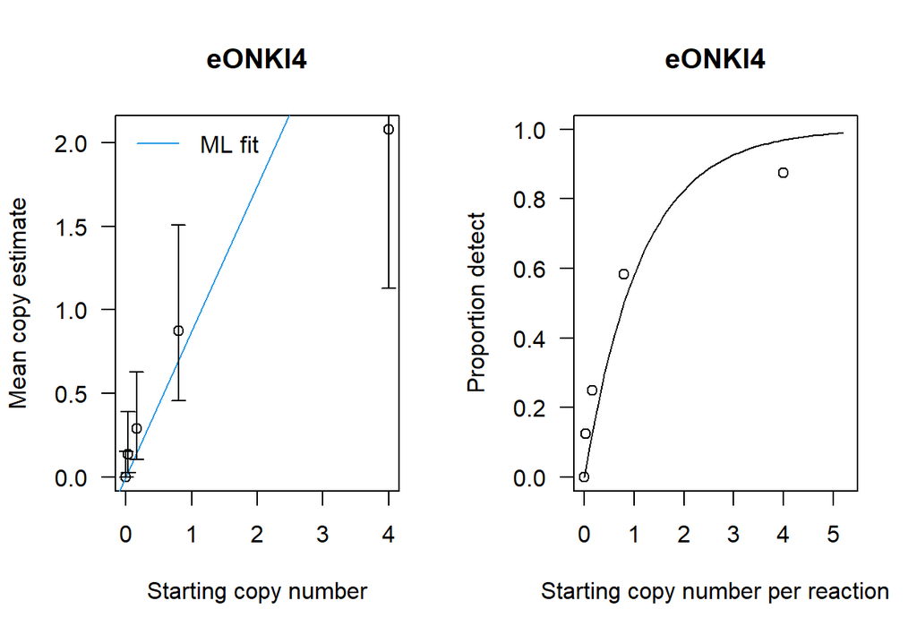

```
##
##
##
##
##  eONKI4
## Convergence= 0
##      Estimate Std.Err Z value  Pr(>z)
## beta    0.872   0.157    5.54 2.9e-08 ***
## ---
## Signif. codes:  0 '***' 0.001 '**' 0.01 '*' 0.05 '.' 0.1 ' ' 1
## LLR test stat= 11.91839 , df=  4 , p-value= 0.01796854
```

## 3.7 Estimate predicted SQ given number detects and technical replicates - no intercept (not shown)

The estimated SQ is easily obtained for given new values of nn0=number of replicates, nd0=number detected and the estimated slope betaS as: Shat <- -(log((nn0 - nd0)/nn0)) / betaS[1] The standard errors are obtained from the Hessian matrix (or via the function CalibS0Or.ddLLik()) .

## 3.8 Estimate predicted SQ given consecutive numbers of detects given number of technical replicates - no intercept

The estimated SQ is easily obtained for given new values of nn0=number of replicates, nd0=number detected and the estimated slope betaS as: Shat <- -(log((nn0 - nd0)/nn0)) / betaS[1] The standard errors are obtained from the Hessian matrix (or via the function CalibS0Or.ddLLik()).

```
##
##  eONKI4
##  ML estimate of SQ for numbers of detects and 8 replicates
##
##
##       NumDetects      SQ0   SE_SQ0
## ---  -----------  -------  -------
## 0              0   0.0000      NaN
## 1              1   0.1531   0.1557
## 2              2   0.3299   0.2415
## 3              3   0.5390   0.3287
## 4              4   0.7949   0.4300
## 5              5   1.1248   0.5613
## 6              6   1.5897   0.7585
## 7              7   2.3848   1.1558
```

[output cut: 93 more lines]

## 3.9 Estimate Poisson models - intercept model

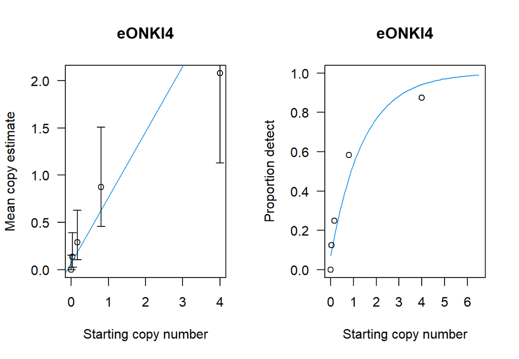

```
##
##
##
##
##  eONKI4
## Convergence= 0
##       Estimate Std.Err Z value  Pr(>z)
## alpha   0.0749  0.0486    1.54    0.12
## beta    0.6939  0.1601    4.33 1.5e-05 ***
## ---
## Signif. codes:  0 '***' 0.001 '**' 0.01 '*' 0.05 '.' 0.1 ' ' 1
## LLR test stat= 7.671079 , df=  3 , p-value= 0.05332185
```

## 3.10 Estimate predicted Sq given number detects and technical replicates - intercept model (not shown)

## 3.11 Estimate predicted SQ given consecutive numbers of detects given number of technical replicates - intercept model

The estimated SQ is easily obtained for given new values of nn0=number of replicates, nd0=number detected and the estimated slope betaS as: Shat <- -(log((nn0 - nd0)/nn0) + betaS[1]) / betaS[2] The standard errors are obtained from the Hessian matrix (or via the function CalibS0.ddLLik()).

```
##
##  eONKI4
##  ML estimate of SQ for numbers of detects and 8 replicates
##
##
##       NumDetects     SQ0   SE_SQ0
## ---  -----------  ------  -------
## 0              0   0.000    0.000
## 1              1   0.084    0.203
## 2              2   0.307    0.303
## 3              3   0.569    0.412
## 4              4   0.891    0.542
## 5              5   1.305    0.714
## 6              6   1.890    0.973
## 7              7   2.889    1.492
```

[output cut: 93 more lines]

## 3.12 Lc, Ld, Lq’s - no intercept model

### 3.12.1 Determine Lc, Ld, Lq (LOB, LOD, LOQ) - no intercept model

Follows Lavagnini and Magno 2007, Mass Spectrometry Reviews *The notation in our eDNA paper is different from the Lavagnini 2007 paper and is shown in brackets here.*

- Lc (*LOB Limit of blank*) = critical level is the assay signal above which a response is reliably attributed to the presence of analyte
- Ld (*Ld = expected number detects out of NN replicates at concentration LOD*) = signal corresponding to an analyte concentration xd (*=LOD Limit of Detection*) level which may be a priori expected to be recognized
- Lq = quantification limit is a signal with a precision which satisfies an expected value ($=\gamma_Q$)

Lc corresponds to a critical response level or a false positive rate, i.e. critical number of detects given NN replicates, above which we would reject the null hypothesis that the concentration/copy number is zero at alpha = alphaLc ($=\gamma_{FP}$). It is the critical response level corresponding to the false positive rate of alphaLc. Essentially, the test is positive if the Y~Binomial(m, p) > Lc. The False Positive Rate is P(Y > Lc | S=0).

Ld is computed to correspond to the false negative rate, beta = betaLd ($=\gamma_{FN}$) here. It is computed so that the probability of observing a new (unknown concentration) response less than or equal to Lc is less than or equal to betaLd. The probability of observing Lc or less detects if the concentration is xd (*=LOD Limit of Detection*) or more is less than or equal to betaLd. The values of Lc depend on the number of replicates, NN, so xd does as well. Ld is the expected number of detects at values xd (*=LOD Limit of Detection*) and NN replicates. False negative rate Ld computation: P(Y <= Lc | p_xd) <= betaLd, ($=\gamma_{FN}$) and solve for xd (*=LOD Limit of Detection*).

Lq is less well defined. The literature suggests using Lq = beta0 + 10 s.e.(beta0), but this uses the normality assumption. Other literature suggests using the “analyte concentration xq (*=LOQ Limit of Quantification*) for which the experimental relative standard deviation of the responses reaches a fixed level ($=\gamma_Q$), for example, the level 0.1.” Lavagnini and Magno 2007. I interpret the term “relative standard deviation” to mean the coefficient of variation, CV = sd/mean.

In the exercise below, we use the fits from the ML models to estimate the Lc, Ld and Lq, for various values of NN replicates for a new observation, i.e. a new (unknown concentration) response number of detects. Both the intercept and no intercept models are considered.

### 3.12.2 Print out LOD (no intercept model) with confidence intervals, by number of replicates

```
##              3    8   16   24   32   48   64   96
## LOD       1.15 0.43 0.21 0.14 0.11 0.07 0.05 0.04
## LOD_lower 0.85 0.32 0.16 0.11 0.08 0.05 0.04 0.03
## LOD_upper 1.77 0.66 0.33 0.22 0.17 0.11 0.08 0.06
```

### 3.12.3 Determine Lc, Ld, Lq (LOB, LOD and LOQ) - intercept model

### 3.12.4 Print out LOD (intercept model) with confidence intervals, by number of replicates

```
##             3    8   16   24   32   48   64    96
## LOB       1.0 2.00 3.00 4.00 5.00 7.00 8.00 11.00
## LOD       2.8 1.21 0.67 0.49 0.41 0.32 0.24  0.18
## LOD_lower 1.8 0.74 0.37 0.25 0.19 0.13 0.07  0.03
## LOD_upper 5.3 2.41 1.42 1.10 0.94 0.78 0.63  0.53
```

### 3.12.5 Estimates, Lc, Ld, Lq (LOB, LOD, LOQ) and confidence limits for a given number of technical reps NN[NNi]

Chooses the model (intercept versus no intercept) with the best LLR test fit, i.e. the largest p-value for the LLR test. A table of values for all assays is printed.

```
## Limits for best choice model for N= 8
```

```
## InterModel      alpha        aSE       beta        bSE        LOB    LOD_Low
##       1.00       0.07       0.05       0.69       0.16       2.00       0.74
##        LOD     LOD_Up    LOQ_Low        LOQ     LOQ_Up
##       1.21       2.41       1.24       1.93       3.73
```

## 3.13 eDNA Manuscript Tables and Graphs (not used in *fishes* manuscript)

*Revised for general use to use all eligible targets.*  
*Revised to output results for both intercept and no intercept models.*

# 4 Cq gBlock section, calibration and estimation

## 4.1 Medians for CqT=Transformed Cq and Cq

```
## [1] "number of zero Cqs:  0"
```

Transformed Cq medians by SQ (nondetect = 0)

|  | 20 | 100 | 500 | 2500 | 12500 | 62500 |
| --- | --- | --- | --- | --- | --- | --- |
| eONKI4 | 16.35 | 17.88 | 21.43 | 23.88 | 26.36 | 28.69 |

Cq medians by SQ (nondetect removed)

|  | 20 | 100 | 500 | 2500 | 12500 | 62500 |
| --- | --- | --- | --- | --- | --- | --- |
| eONKI4 | 33.65 | 32.12 | 28.57 | 26.12 | 23.64 | 21.31 |

## 4.2 Plot transformed Cq versus log_10 SQ

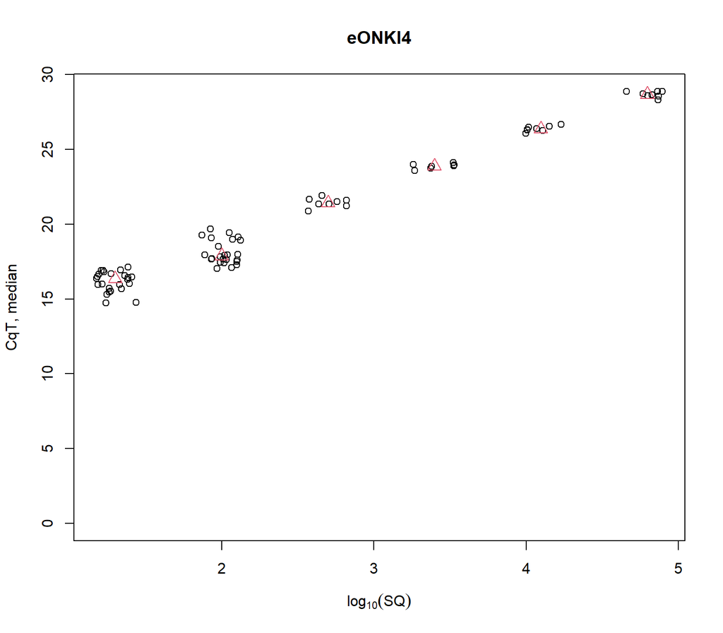

## 4.3 High copy standard curve using Weighted Least Squares and gBlock data

Fit regression models to Cq’s for calibration of SQ on log_10 SQ scale using method of Lavignini et al. 2007, bottom page 11. The R code names follow the notation of Laivgnini et al. 2007. For example, Xwhat is $\hat{X_w}$.

Aside: Kralik, Petr and Ricchi, Matteo (2017) “A basic guide to real time PCR in microbial diagnostics: Definitions, parameters, and everything”, Frontiers in Microbiology, 1-9.

Mathematical principle of qPCR.

$N_n = N_0 \times (1 + E)^n$.

$N_n$ is the number of PCR amplicons after $n$ cycles, $N_0$ is the initial number of template copies in the sample, E is the PCR efficiency that can assume values in the range from 0 to 1, n is the number of cycles.

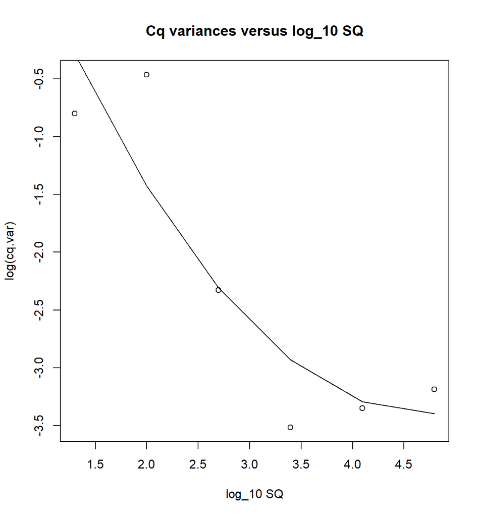

```
## Model for the variances/weights for inverse regression which can be used to estimate weights for a new sample.
##
## Call:
## lm(formula = Cq ~ L10.SQ, data = DATz.df, subset = indcal, weights = 1/Cq.var)
##
## Weighted Residuals:
##      Min       1Q   Median       3Q      Max
## -2.08556 -0.67820  0.09084  1.13515  2.61088
##
## Coefficients:
##             Estimate Std. Error t value Pr(>|t|)
## (Intercept) 38.48862    0.15055  255.66   <2e-16 ***
## L10.SQ      -3.61140    0.04003  -90.22   <2e-16 ***
## ---
## Signif. codes:  0 '***' 0.001 '**' 0.01 '*' 0.05 '.' 0.1 ' ' 1
##
## Residual standard error: 1.124 on 78 degrees of freedom
## Multiple R-squared:  0.9905, Adjusted R-squared:  0.9904
## F-statistic:  8139 on 1 and 78 DF,  p-value: < 2.2e-16
```

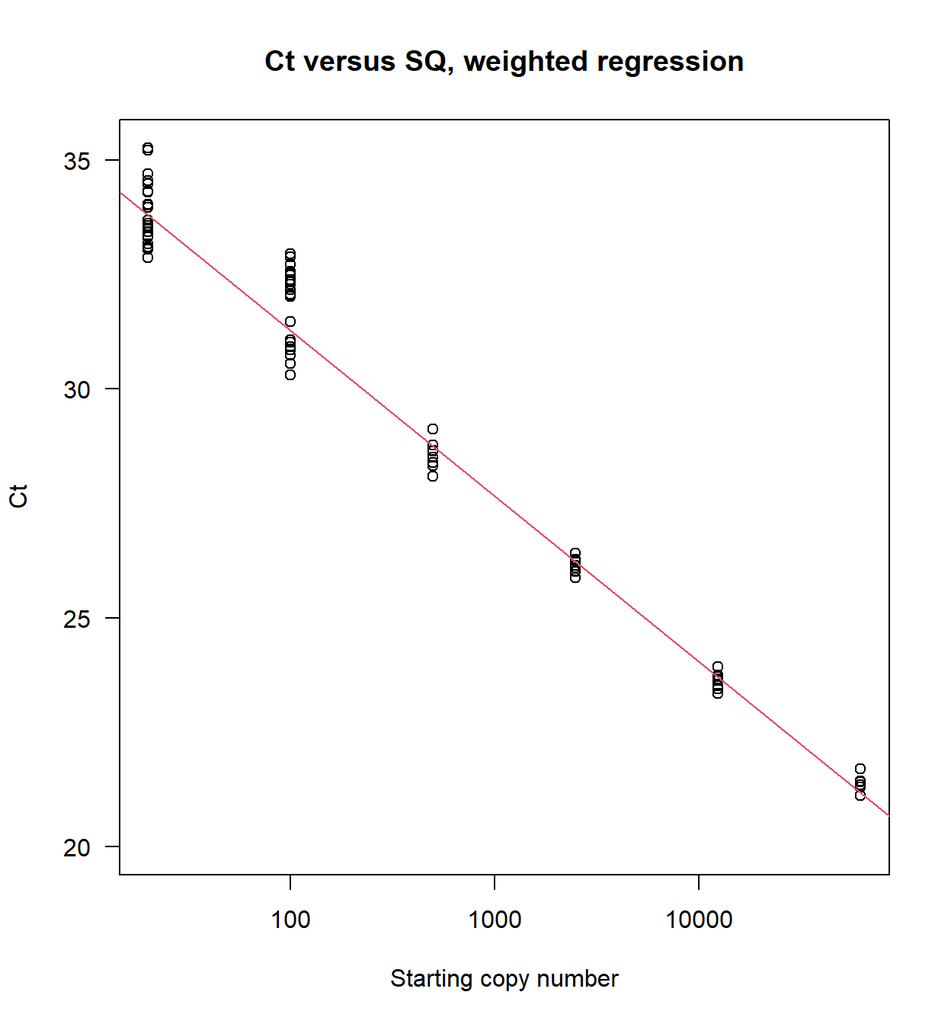

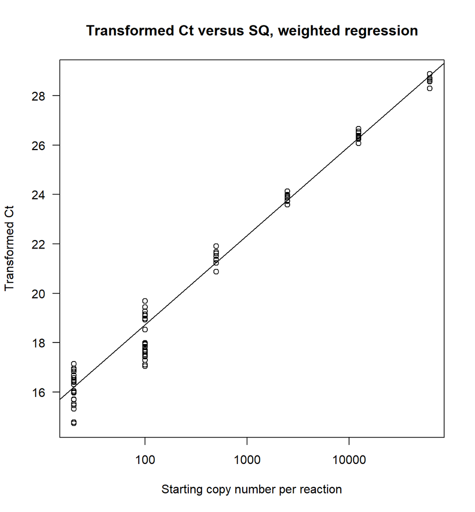

```
##
## Call:
## lm(formula = CqT ~ L10.SQ, data = DATz.df, subset = indcal, weights = 1/Cq.var)
##
## Weighted Residuals:
##      Min       1Q   Median       3Q      Max
## -2.61088 -1.13515 -0.09084  0.67820  2.08556
##
## Coefficients:
##             Estimate Std. Error t value Pr(>|t|)
## (Intercept) 11.51138    0.15055   76.46   <2e-16 ***
## L10.SQ       3.61140    0.04003   90.22   <2e-16 ***
## ---
## Signif. codes:  0 '***' 0.001 '**' 0.01 '*' 0.05 '.' 0.1 ' ' 1
##
## Residual standard error: 1.124 on 78 degrees of freedom
## Multiple R-squared:  0.9905, Adjusted R-squared:  0.9904
## F-statistic:  8139 on 1 and 78 DF,  p-value: < 2.2e-16
##
## eONKI4  E= 0.891911 efficiency
## eONKI4 OLS coefs  38.84488 -3.682191
## eONKI4 WLS coefs  38.48862 -3.611403
## eONKI4 CVs by SQ
##         20        100        500       2500      12500      62500
## 0.14416112 0.12006365 0.03146560 0.01395588 0.01259780 0.01184782
```

# 5 Density Experiment

## 5.1 Load in data from file ‘eco’

## 5.2 Estimate Copy number for Density data using weighted LS in chunk ‘calib’

```
##  FishF  TankF       Tank            Fish        TCTSCTFmean      TCTSCTFsd
##  1 :4   19:7   Min.   :19.00   Min.   : 1.00   Min.   :12.59   Min.   :0.4686
##  2 :4   20:7   1st Qu.:19.75   1st Qu.: 2.00   1st Qu.:16.03   1st Qu.:0.6794
##  4 :4   21:7   Median :20.50   Median : 8.00   Median :17.23   Median :0.9109
##  8 :4   24:7   Mean   :21.00   Mean   :18.29   Mean   :17.38   Mean   :1.0507
##  16:4          3rd Qu.:21.75   3rd Qu.:32.00   3rd Qu.:18.96   3rd Qu.:1.1003
##  32:4          Max.   :24.00   Max.   :65.00   Max.   :21.75   Max.   :4.0045
##  65:4
##    TCTSCTFmed      CTSCTFmean       CTSCTFsd        CTSCTFmed
##  Min.   :13.38   Min.   :28.25   Min.   :0.2947   Min.   :28.02
##  1st Qu.:16.07   1st Qu.:31.04   1st Qu.:0.6563   1st Qu.:31.02
##  Median :17.10   Median :32.77   Median :0.8946   Median :32.90
##  Mean   :17.49   Mean   :32.55   Mean   :0.9564   Mean   :32.51
##  3rd Qu.:18.98   3rd Qu.:33.97   3rd Qu.:1.1003   3rd Qu.:33.93
##  Max.   :21.98   Max.   :36.52   Max.   :2.6110   Max.   :36.62
##
##     Biomass           l2Bio          numSCTF
##  Min.   :  5.69   Min.   :2.508   Min.   :4.000
##  1st Qu.: 11.38   1st Qu.:3.508   1st Qu.:5.000
##  Median : 43.48   Median :5.442   Median :5.000
##  Mean   :102.70   Mean   :5.482   Mean   :4.964
##  3rd Qu.:174.21   3rd Qu.:7.445   3rd Qu.:5.000
##  Max.   :380.38   Max.   :8.571   Max.   :5.000
##
```

```
##
## Call:
## lm(formula = Xl2what ~ l2Bio, data = eco.SC.TF, weights = (1/Xwhat.se^2))
##
## Weighted Residuals:
##     Min      1Q  Median      3Q     Max
## -8.2694 -0.4669  0.8505  2.1762  8.3466
##
## Coefficients:
##             Estimate Std. Error t value Pr(>|t|)
## (Intercept)  -0.1401     0.6525  -0.215    0.832
## l2Bio         0.9677     0.1100   8.800 2.83e-09 ***
## ---
## Signif. codes:  0 '***' 0.001 '**' 0.01 '*' 0.05 '.' 0.1 ' ' 1
##
## Residual standard error: 3.292 on 26 degrees of freedom
## Multiple R-squared:  0.7487, Adjusted R-squared:  0.739
## F-statistic: 77.45 on 1 and 26 DF,  p-value: 2.828e-09
```

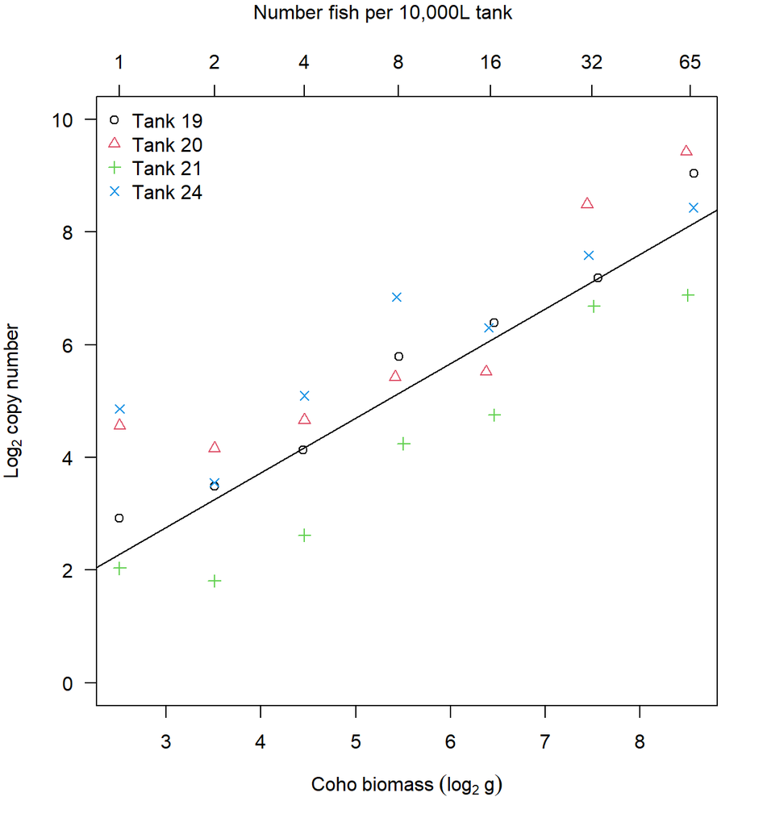

```
## Model estimates(predict) and actuals by Number of Fish
```

```
##                        1        2         4         8        16         32
## mean log2 Copy  3.595473 3.252432  4.127450  5.577412  5.739707   7.487296
## mean copy      12.087747 9.529707 17.477780 47.749443 53.434774 179.432331
## predict_copy    4.881558 9.547025 18.011992 35.135918 67.549443 138.133428
## predict_log2    2.287342 3.255051  4.170886  5.134875  6.077872   7.109919
##                        65
## mean log2 Copy   8.441016
## mean copy      347.535470
## predict_copy   277.370960
## predict_log2     8.115673
```

### 5.2.1 Ggplot density plot

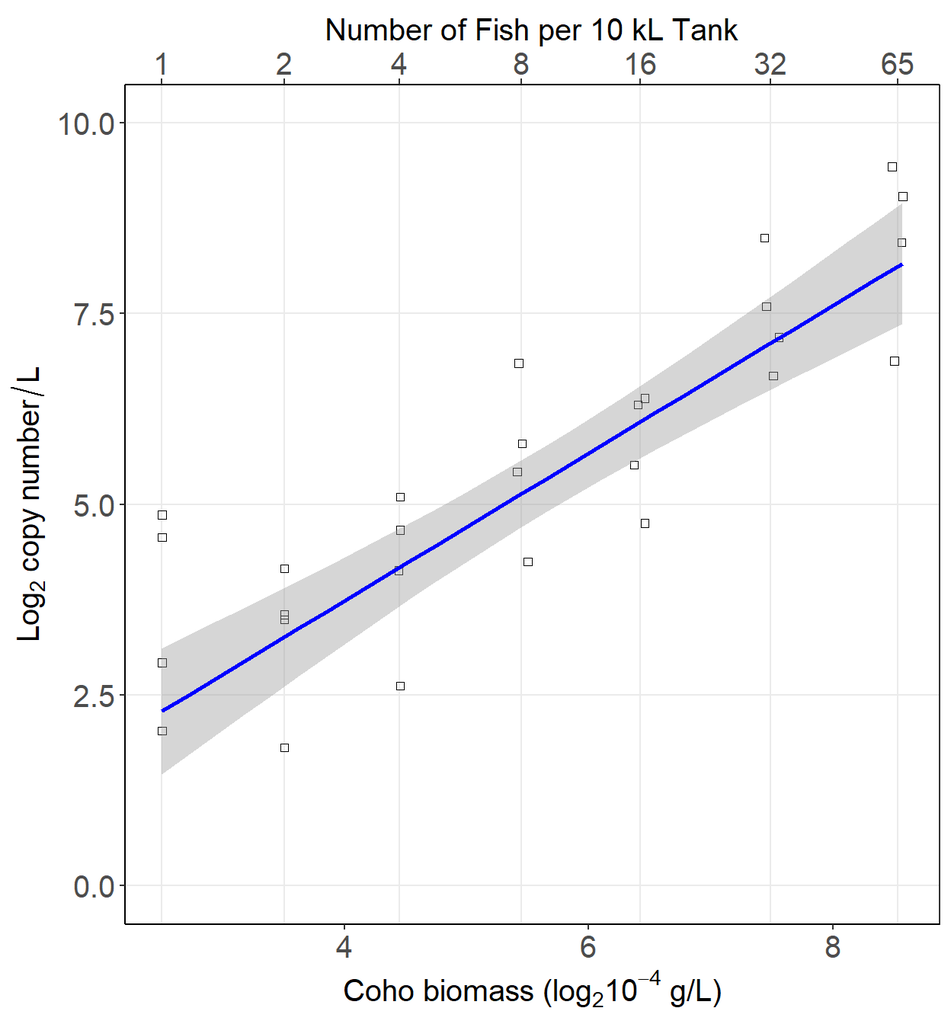

# 6 Dilution/Flow experiment

## 6.1 Load data from file flowFT; estimate Copy number for Flow/Tank Binomial data

Uses CalibS0.table0 generated using no intercept model for eONKI4 in chunk ‘MLES0fits0vec’ above. Estimate SQ given number of detects in data flow.FT.

```
## Dilution data by Flow and Tank
```

```
##    FlowN Tank TankF FlowF  TCTFTmean   TCTFTsd CTFTmean    CTFTsd numFT
## 1     10   19    19    10 16.3216250 1.9333940 33.67938 1.9333940    32
## 2     10   20    20    10 16.8313125 0.8704818 33.16969 0.8704818    32
## 3     10   21    21    10 15.7397500 2.2366888 34.26125 2.2366888    24
## 4     10   24    24    10 17.2001667 1.5784773 32.80083 1.5784773    24
## 5     20   19    19    20 15.7260000 0.7295204 34.27500 0.7295204    16
## 6     20   20    20    20 15.9968333 1.6171067 34.00417 1.6171067    24
## 7     20   21    21    20 16.0022500 1.1864427 33.99875 1.1864427    24
## 8     20   24    24    20 15.9818333 0.8093417 34.01917 0.8093417    24
## 9     40   19    19    40  5.9260000 6.6034484 37.07273 0.8487649    24
## 10    40   20    20    40 13.4660000 3.0647775 35.94957 1.1046739    24
## 11    40   21    21    40 13.6572500 4.4014403 35.10227 1.3571221    24
## 12    40   24    24    40  8.0685000 6.4241435 37.09200 0.9251888    24
## 13    80   19    19    80  0.4101667 2.0044991 40.18000        NA    24
## 14    80   20    20    80  0.6505833 2.2148226 42.20500 1.1950105    24
```

[output cut: 35 more lines]

```
## Data with Flow>=40 and Binomial-Poisson copy number estimates, SQ0
```

```
##    FlowN Tank TankF FlowF  TCTFTmean  TCTFTsd CTFTmean    CTFTsd numFT ndetects
## 9     40   19    19    40  5.9260000 6.603448 37.07273 0.8487649    24       11
## 10    40   20    20    40 13.4660000 3.064777 35.94957 1.1046739    24       23
## 11    40   21    21    40 13.6572500 4.401440 35.10227 1.3571221    24       22
## 12    40   24    24    40  8.0685000 6.424143 37.09200 0.9251888    24       15
## 13    80   19    19    80  0.4101667 2.004499 40.18000        NA    24        1
## 14    80   20    20    80  0.6505833 2.214823 42.20500 1.1950105    24        2
## 15    80   21    21    80  1.9897500 4.547596 38.06750 0.5885788    24        4
## 16    80   24    24    80  0.4964167 2.427036 38.11000        NA    24        1
## 17   160   19    19   160  0.0010000 0.000000      NaN        NA    24        0
## 18   160   20    20   160  0.3439167 1.679942 41.77000        NA    24        1
## 19   160   21    21   160  0.0010000 0.000000      NaN        NA    24        0
## 20   160   24    24   160  1.4860000 4.022667 38.12000 0.9232551    24        3
## 21  1000   19    19  1000  0.0010000 0.000000      NaN        NA    32        0
## 22  1000   20    20  1000  0.4614167 2.255572 38.95000        NA    24        1
```

[output cut: 19 more lines]

## 6.2 Estimate Copy number for high copy number Flow/Dilution data

Uses calibration weighted linear regression model from above, chunk ‘calib’

```
## High copy number Dilution data with copy number estimated, SQest
```

```
##   FlowN Tank TankF FlowF TCTFTmean   TCTFTsd CTFTmean    CTFTsd numFT ndetects
## 1    10   19    19    10  16.32163 1.9333940 33.67938 1.9333940    32       32
## 2    10   20    20    10  16.83131 0.8704818 33.16969 0.8704818    32       32
## 3    10   21    21    10  15.73975 2.2366888 34.26125 2.2366888    24       24
## 4    10   24    24    10  17.20017 1.5784773 32.80083 1.5784773    24       24
## 5    20   19    19    20  15.72600 0.7295204 34.27500 0.7295204    16       16
## 6    20   20    20    20  15.99683 1.6171067 34.00417 1.6171067    24       24
## 7    20   21    21    20  16.00225 1.1864427 33.99875 1.1864427    24       24
## 8    20   24    24    20  15.98183 0.8093417 34.01917 0.8093417    24       24
##      SQest L10SQest   L10SQse
## 1 21.46263 1.331683 0.3431055
## 2 29.70405 1.472816 0.1578785
## 3 14.81021 1.170561 0.4571917
## 4 37.57956 1.574952 0.3237664
## 5 14.68094 1.166754 0.1855052
## 6 17.44809 1.241748 0.3314746
## 7 17.50845 1.243248 0.2444035
## 8 17.28201 1.237594 0.1687485
```

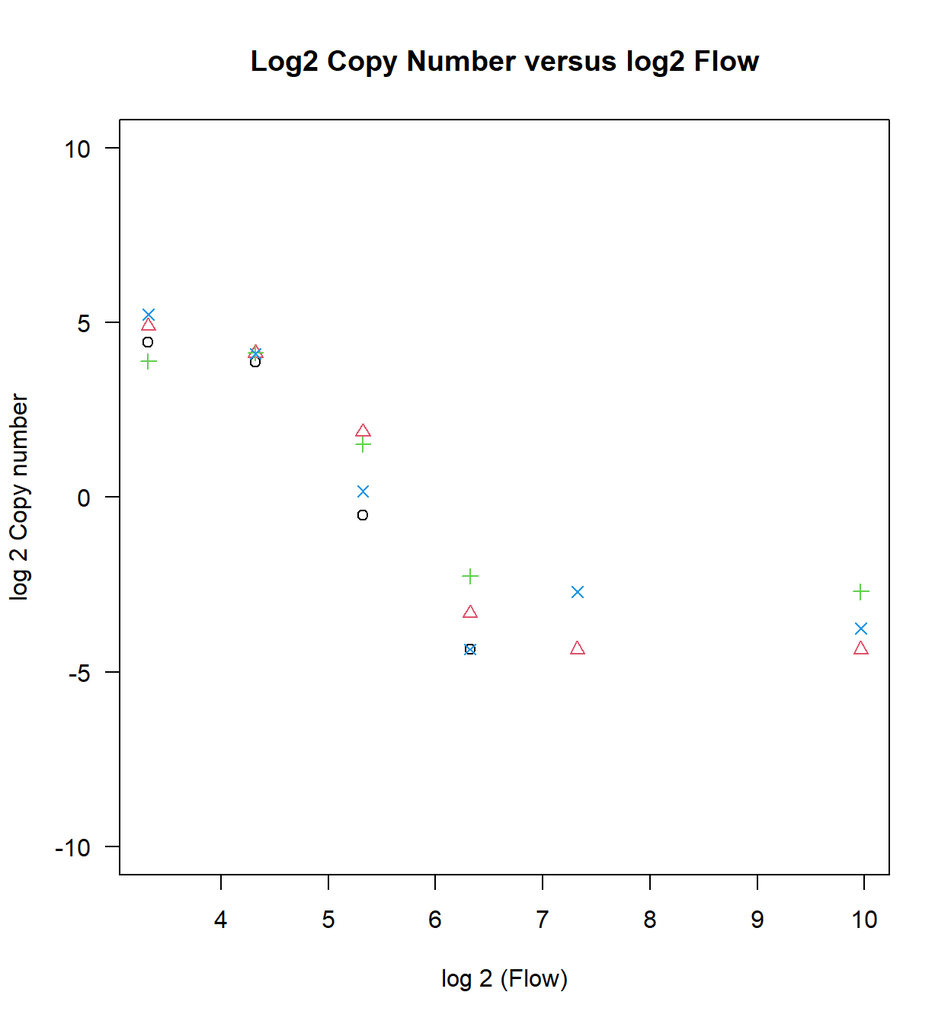

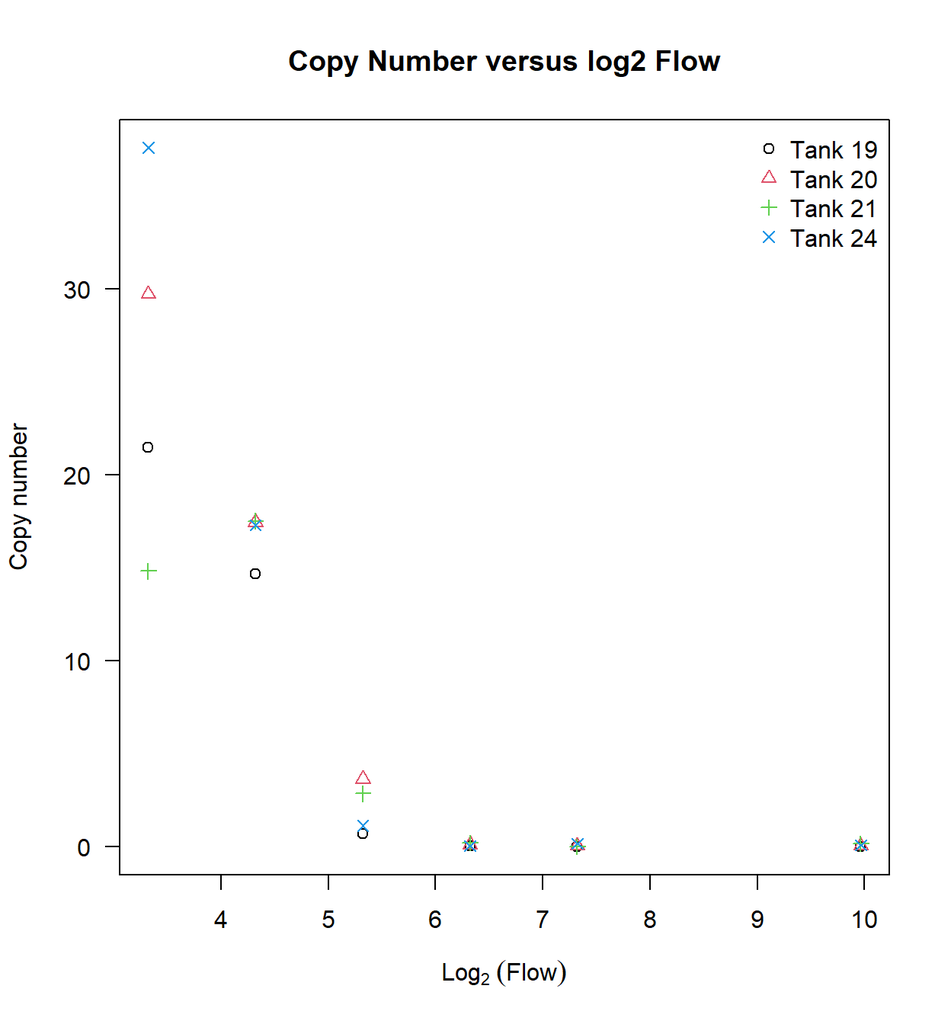

## 6.3 Extra 40Kl Dilution Table

```
##    Sort.Code          Tank       TankF      FlowN    FlowF     TCTSCmean
##  Min.   :41.00   Min.   :19.00   19:3   Min.   :40   40:12   Min.   : 3.160
##  1st Qu.:43.75   1st Qu.:19.75   20:3   1st Qu.:40           1st Qu.: 6.652
##  Median :46.50   Median :20.50   21:3   Median :40           Median :11.105
##  Mean   :46.50   Mean   :21.00   24:3   Mean   :40           Mean   :10.279
##  3rd Qu.:49.25   3rd Qu.:21.75          3rd Qu.:40           3rd Qu.:14.066
##  Max.   :52.00   Max.   :24.00          Max.   :40           Max.   :16.045
##     TCTSCsd          CTSCmean         CTSCsd           numSC      ndetects
##  Min.   :0.5893   Min.   :33.96   Min.   :0.5845   Min.   :8   Min.   :2.000
##  1st Qu.:1.5242   1st Qu.:35.77   1st Qu.:0.6379   1st Qu.:8   1st Qu.:4.000
##  Median :5.3869   Median :36.55   Median :0.8216   Median :8   Median :6.500
##  Mean   :4.4004   Mean   :36.36   Mean   :0.9423   Mean   :8   Mean   :5.917
##  3rd Qu.:6.3013   3rd Qu.:36.94   3rd Qu.:1.0995   3rd Qu.:8   3rd Qu.:8.000
##  Max.   :7.1248   Max.   :38.05   Max.   :1.5854   Max.   :8   Max.   :8.000
```

```
## Use Weighted regression Cq model to estimate copy number Xwhat.40 for 100% detects
```

```
## Ignore Xwhat.40 for <100% detects and use Binomial-Poisson model instead.
```

```
##       ndetects   CTmean  TCTmean  Xwhat.40
##  [1,]        4 36.72250  6.63975  3.083468
##  [2,]        3 38.05000  4.48225  1.322677
##  [3,]        4 36.69000  6.65600  3.148029
##  [4,]        7 36.41571 11.88725  3.749632
##  [5,]        8 35.49375 14.50725  6.749649
##  [6,]        8 35.99750 14.00350  4.895448
##  [7,]        8 35.74625 14.25475  5.745975
##  [8,]        8 33.95625 16.04475 17.989373
##  [9,]        6 35.77167 10.67225  5.653610
## [10,]        7 36.81571 11.53725  2.905550
## [11,]        2 37.36500  3.15975  2.047061
## [12,]        6 37.32333  9.50850  2.102172
```

# 7 Background estimation

## 7.1 Background estimate from Density experiment negative controls

```
## Density background estimate:   0.06109982
```

```
## Density negative controls, ndetect, nreps
```

```
##    nd numSC
##    22   424
```

```
## Mean of individual Density background estimates:   0.06940534
```

## 7.2 Background estimate from Dilution data

Estimate of background using flow negative controls.

```
##    Sort.Code Tank TankF FlowN FlowF TCTSCmean  TCTSCsd CTSCmean    CTSCsd numSC
## 1        113   19    19     0     0   1.43600 4.058793   38.520        NA     8
## 2        114   19    19     0     0   1.67100 4.723473   36.640        NA     8
## 3        115   19    19     0     0   0.00100 0.000000      NaN        NA     8
## 4        116   20    20     0     0   0.00100 0.000000      NaN        NA     8
## 5        117   20    20     0     0   2.96975 5.497343   38.125 0.1484924     8
## 6        118   20    20     0     0   0.00100 0.000000      NaN        NA     8
## 7        119   21    21     0     0   0.00100 0.000000      NaN        NA     8
## 8        120   21    21     0     0   0.00100 0.000000      NaN        NA     8
## 9        121   21    21     0     0   2.42475 4.494498   40.305 0.6434672     8
## 10       122   24    24     0     0   0.00100 0.000000      NaN        NA     8
## 11       123   24    24     0     0   0.00100 0.000000      NaN        NA     8
## 12       124   24    24     0     0   0.00100 0.000000      NaN        NA     8
##    ndetects
## 1         1
## 2         1
## 3         0
## 4         0
## 5         2
## 6         0
## 7         0
## 8         0
## 9         2
## 10        0
## 11        0
## 12        0
```

```
## Mean background of individual flow negative controls:   0.08050365
```

## 7.3 Background estimate from Density and Dilution data

```
## Background copy number estimate:   0.06347212
```

```
## ndetects:   28 nreps:  520
```

# 8 BACKGROUND Limits of Detection using estimated background SQBboth, No intercept model

For the ordinary Limit of detection, Lc (or LOB) is the critical value for the test of the null hypothesis that SQ=0. Here the null hypothesis is that SQB=S_Background (using SQBboth) and we compute a critical value LOB-B, Limit of Background Blank. We also compute LOD-B, Limit of Background Detection.

```
## Background estimate and confidence interval
##
## 0.06347212   ( 0.0468951 0.09817675 )
```

## 8.1 Print out BACKGROUND limits of detection with confidence intervals, by number of replicates

```
##                3    8   16   24   32   40   48   64   96
## LOB-B       1.00 2.00 3.00 3.00 4.00 5.00 5.00 7.00 9.00
## LOB-Bcn     0.46 0.33 0.24 0.15 0.15 0.15 0.13 0.13 0.11
## LOD-B       2.29 1.05 0.62 0.40 0.35 0.32 0.27 0.25 0.20
## LOD-B_lower 1.69 0.78 0.46 0.29 0.26 0.24 0.20 0.18 0.15
## LOD-B_upper 3.55 1.62 0.96 0.61 0.54 0.50 0.41 0.39 0.30
```

## 8.2 Fit Bent Cable model to flow data mean over (Flow/Tank) copy numbers

```
## Breakpoint alphahat:   7.214288 , 2^alphahat:   148.4968
```

```
##
## Call:
## stats::lm(formula = y ~ x + q)
##
## Residuals:
##         10         20         40         80        160       1000
## -9.829e-01  1.086e+00  7.770e-01 -8.800e-01  6.813e-05 -6.560e-06
##
## Coefficients:
##             Estimate Std. Error t value Pr(>|t|)
## (Intercept)  14.6419     2.0144   7.269  0.00537 **
## x            -2.6986     0.3759  -7.179  0.00557 **
## q             3.0509     0.8033   3.798  0.03205 *
## ---
## Signif. codes:  0 '***' 0.001 '**' 0.01 '*' 0.05 '.' 0.1 ' ' 1
##
## Residual standard error: 1.084 on 3 degrees of freedom
## Multiple R-squared:  0.9578, Adjusted R-squared:  0.9297
## F-statistic: 34.07 on 2 and 3 DF,  p-value: 0.00866
```

## 8.3 Intersections with Bent cable model

```
## [1] "Bent cable model intersections"
```

```
##               Log2copy  Log2Vol       Copy     VolKL
## Background -3.97773327 7.061184 0.06347212 133.54516
## LODB_8      0.07019178 5.391873 1.04985623  41.98707
## Lcx_8      -1.59991565 6.026211 0.32989627  65.17340
## LODB_24    -1.33488234 5.926053 0.39642440  60.80224
## Lcx_24     -2.70721201 6.426846 0.15312566  86.03464
## LODB_40    -1.63342071 6.026211 0.32232305  65.17340
## Lcx_40     -2.70721201 6.426846 0.15312566  86.03464
```

## 8.4 GGplot log2 Flow/Dilution plot using mean copy numbers

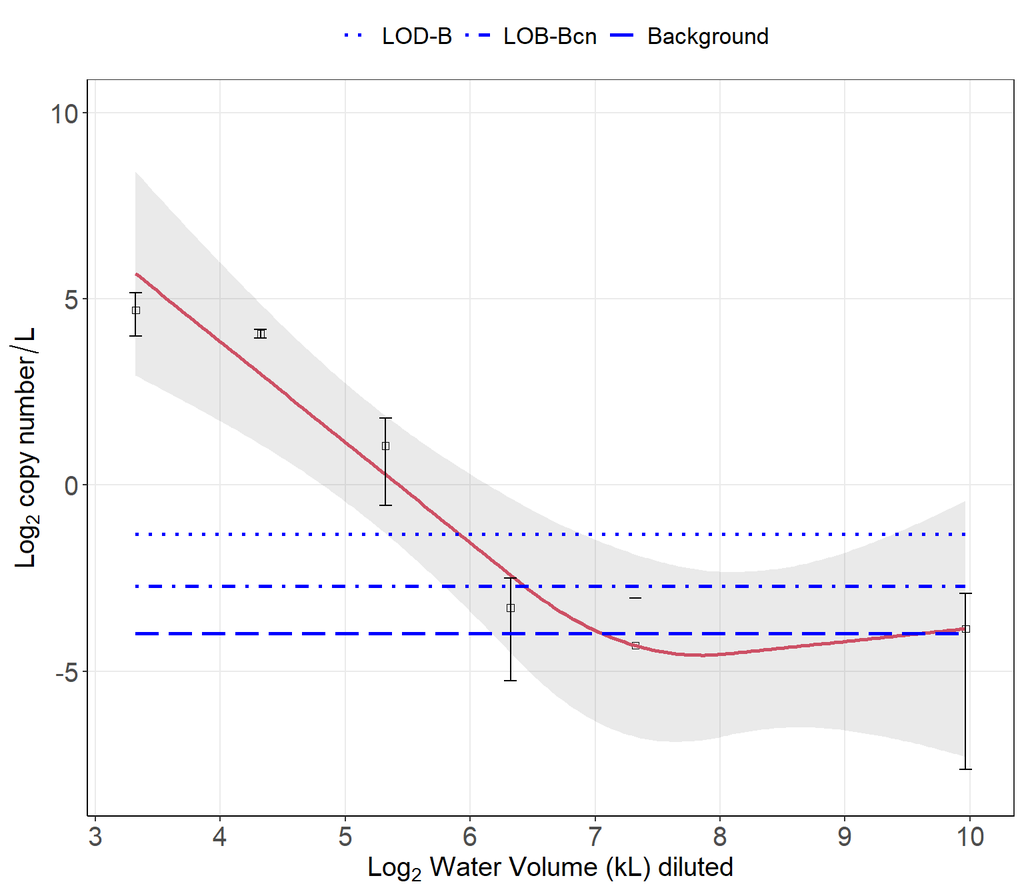

```
## 24 technical replicates
```

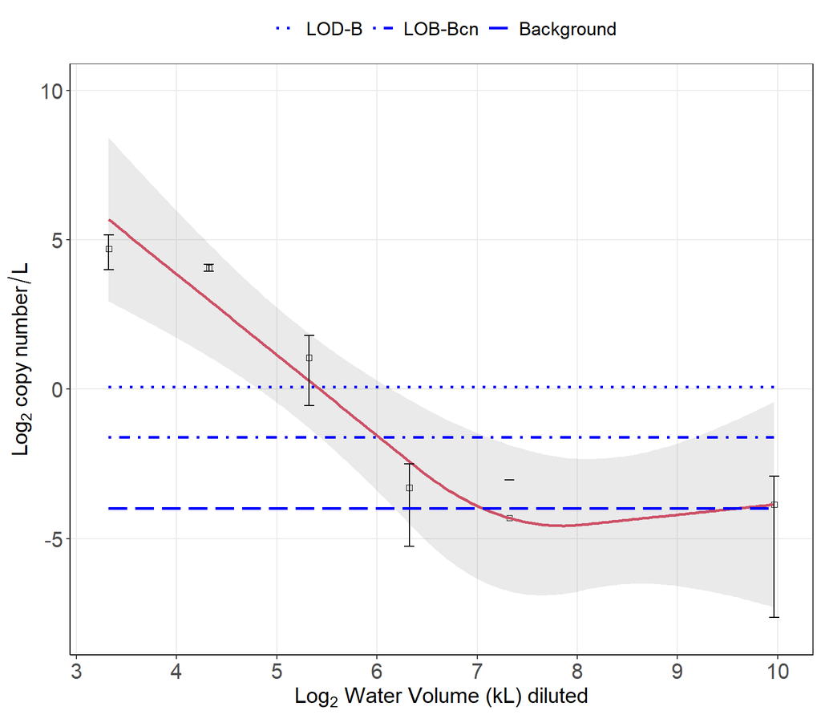

```
## 8 technical replicates
```